##### **Group 13** by Hyungjoon Choi | Jing Mu | William Robert Raikes | Nianyao Zuo

## Health Insurance Coverage in the U.S.

### Abstract

As the Affordable Care Act, so called ObamaCare, was signed into law in 2010, it is reported that there has been a high increase in a number of health insurance coverage. Especially, a bulk of its provisions, taxes, and programs rolled out in 2013 and 2014, and it was expected that a larger number of people would be enrolled for the care during the period.

Going forward, it is intriguing to look at what really happened, to what extent it brought impacts, and who were the driving force of this change between 2013 and 2014. From 2013 to 2014, there was a 3% increase in health insurance coverage, as the percentage of Americans who had health insurance coverage went from 87.1% to 90.0%, a marked increase year-over-year.

We first analyzed only 2013 population data to see who had more or less health insurance, and to what extent they had. Then, we rolled it forward to the next year to see if there was any greater change in a certain group of people, if it looked reasonable, and eventually if ObamaCare brought impacts over the year.

### Data Processing

Example table of grouping:

| Income Level | Income Range |
| --- | --- |
| Low | Less than $30,000 |
| Mid-low | Between $30,000 and $55,000 |
| Median | Between $55,000 and $95,000 |
| Mid-high | Between $95,000 and $150,000 |
| High | More than $150,000 |

Similar methods applied to the other variables to be categorical.

pusa_13<-fread(“ss13pusa.csv”) pusb_13<-fread(“ss13pusb.csv”) pus_13 <- rbind(pusa_13,pusb_13)

pusa_14<-fread(“ss14pusa.csv”) pusb_14<-fread(“ss14pusb.csv”) pus_14 <- rbind(pusa_14, pusb_14)

rm(pusa_13, pusb_13, pusa_14, pusb_14)

pus_13selected <- subset(pus_13, select=c(‘ST’,‘AGEP’,‘WAGP’,‘SEX’,‘RAC1P’,‘MAR’,‘SCHL’,‘HICOV’, ‘PWGTP’,‘PRIVCOV’,‘PUBCOV’)) pus_13selected$year <- rep(2013, nrow(pus_13selected))

pus_14selected <- subset(pus_14, select=c(‘ST’,‘AGEP’,‘WAGP’,‘SEX’,‘RAC1P’,‘MAR’,‘SCHL’,‘HICOV’, ‘PWGTP’,‘PRIVCOV’,‘PUBCOV’)) pus_14selected$year <- rep(2014, nrow(pus_14selected))

pusa <- tbl_df(rbind(pus_13selected, pus_14selected, fill = TRUE)) pusa$year <- as.factor(pusa$year) save(pusa, file = ‘pusa.csv’)

```r
pusa <- read.csv('pusa.csv')
```

```r
#regrouping
pusa1 <-
  pusa %>%
  mutate(age = ifelse(AGEP %in% 0:18, "Under 18", ifelse(AGEP %in% 18:29, "20s", ifelse(AGEP %in% 30:39, "30s", ifelse(AGEP %in% 40:49, "40s", ifelse(AGEP %in% 50:59, "50s", ifelse(AGEP %in% 60:69, "60s", "Above 70"))))))) %>%
  mutate(income = ifelse(WAGP %in% 0:30000, "Low", ifelse(WAGP %in% 30000:55000, "Mid-low", ifelse(WAGP %in% 55000:95000, "Midian", ifelse(WAGP %in% 95000:150000, "Mid-high", "High")))))%>%
  mutate(Gender=ifelse(SEX== 1, "Male", ifelse(SEX== 2, "Female", NA)))%>%
  mutate(Race=ifelse(RAC1P==1, "White", ifelse(RAC1P==2, "Black", ifelse(RAC1P==3, "American Indian", ifelse(RAC1P==6, "Asian", "Others")))))%>%
  mutate(MARR=ifelse(MAR==1, "Married", ifelse(MAR==2, "Widowed", ifelse(MAR==3, "Divorced", ifelse(MAR==4, "Separated", "Never Married")))))%>%
  mutate(Edu=ifelse(SCHL %in% 0:15, "No Highschool", ifelse(SCHL==16, "High School", ifelse(SCHL==17, "GED", ifelse(SCHL %in% 18:19, "College Credit", ifelse(SCHL==21, "Bachelor's", ifelse(SCHL==22, "Master's", ifelse(SCHL==24, "PhD", "Other"))))))))%>%
  ungroup()

#rearrange the factors
pusa1$Gender<-factor(pusa1$Gender, levels=c("Male","Female"))
pusa1$income<-factor(pusa1$income, levels=c("Low", "Mid-low", "Midian", "Mid-high", "High"))
pusa1$age<-factor(pusa1$age, levels=c("Under 18", "20s", "30s", "40s", "50s", "60s", "Above 70"))
pusa1$Edu<-factor(pusa1$Edu, levels=c("No Highschool", "High School", "GED", "College Credit", "Bachelor's", "Master's", "PhD", "Other"))
pusa1$Race<-factor(pusa1$Race, levels=c("White", "Black", "American Indian", "Asian", "Others"))
```

## 1. Some facts of health insurance coverage in 2013

### > Demographics

This brief exploratory analysis looks to achieve two things:

- Understand some basic differences between the types of individuals who had health insurance vs. those who did not, by comparing this rate to that of the national average (87.1%).
- Identify the likely characteristics of indivuals who were more likely to enroll from the 2013 to 2014 period - which seems plausible to attribute to the Affordable Care Act.

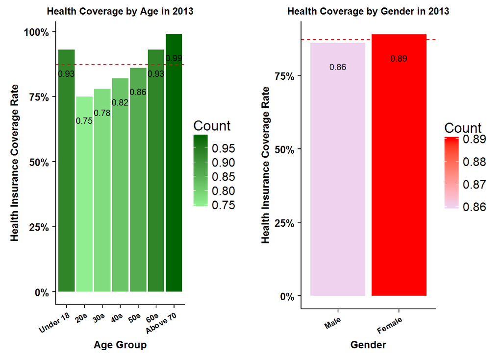

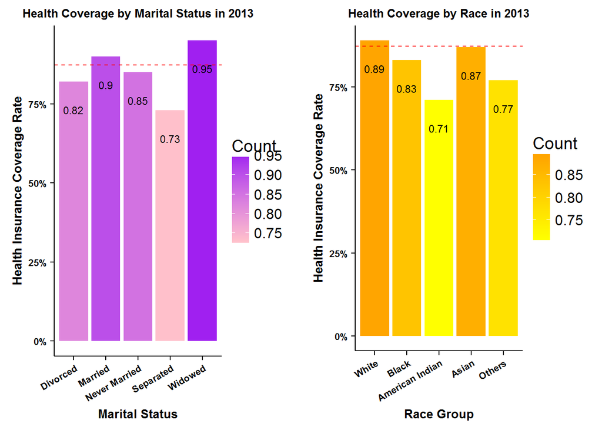

- From a few selected demographics, it appears that females are only slightly more likely to have health insurance compared to males (86% vs. 89%).
- When it comes to age, the older you are, the more likely you are to be insured (with the exception of minors younger than 18 years). In fact, over 99% of those 70 or older had some form of health insurance (predictably Medicare).
- Minorities also seemed to be less likely to be insured, especially American Indian. A group, ‘others’, include other minority groups such as Alaskan or Hawaiiwan.
- Lastly, those who are married or widowed were more likely to be insured, as those who were divorced or separated were less likely.

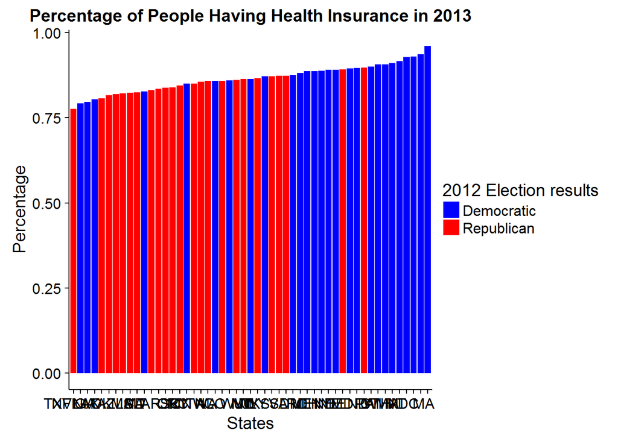

```r
ggplot(ins13, aes(x=reorder(abbr,ins_per), y=ins_per, fill=factor(vote)))+
  geom_bar(stat='identity')+scale_fill_manual(name='2012 Election results', values=c('blue','red'))+
  ylab("Percentage")+xlab("States")+ggtitle("Percentage of People Having Health Insurance in 2013")
```

[figure not shown]

```r
#####Heat map(difference between public and private)
priv_cov13 <- subset(ins13, select = c('name','priv_per'))
priv_cov13$name <- tolower(priv_cov13$name)
colnames(priv_cov13) <- c('region', 'value')
pm1 <- state_choropleth(priv_cov13, title='Percentage of Private Health Insurance Coverage 2013')

pub_cov13 <- subset(ins13, select = c('name','pub_per'))
pub_cov13$name <- tolower(pub_cov13$name)
colnames(pub_cov13) <- c('region', 'value')
pm2 <- state_choropleth(pub_cov13, title='Percentage of Public Health Insurance Coverage 2013')
plot_grid(pm1,pm2,ncol=2,rel_heights=c(1,1))
```

[output not shown]

```r
#############
```

### > Income & Education Level

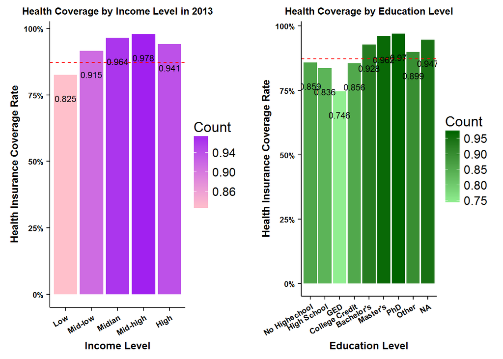

## 2. Changes Year-over-Year

So as the Affordable Care Act continues to ramp up, how has this changed the likelihood of certain individuals likely to receive coverage?

### > Demographics

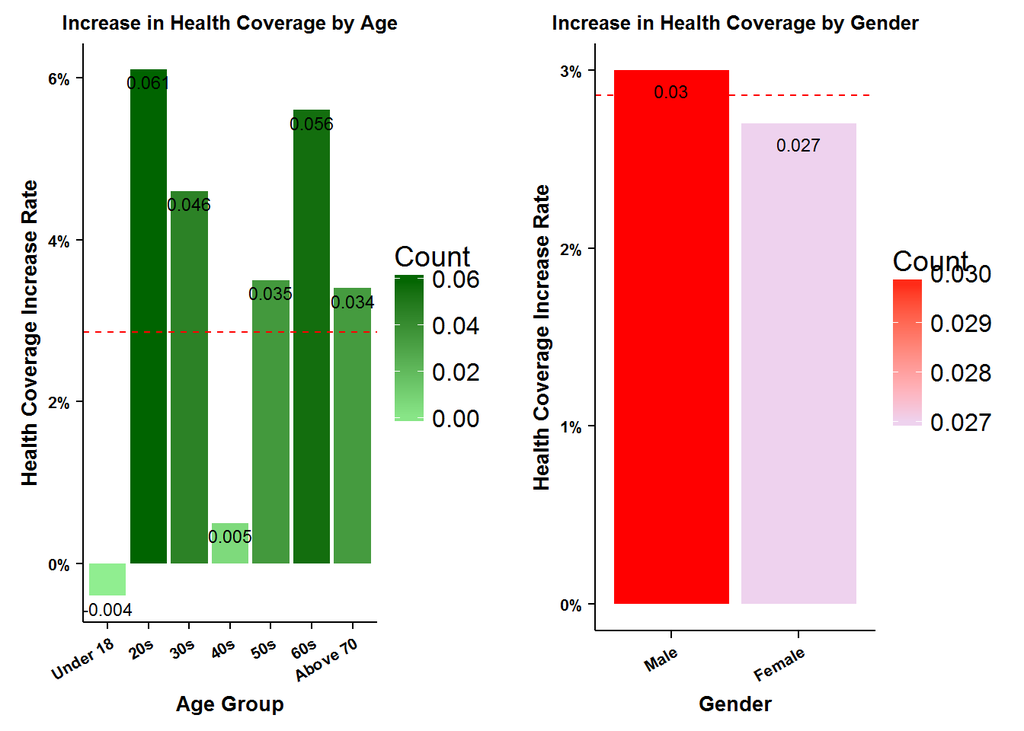

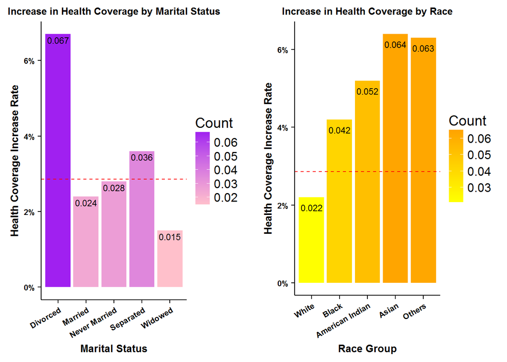

- There was no difference between genders. They are equally likely to purchase health insurance.
- People in an age group of ‘20s’ (18 to 29) and older (60-69) individuals were more likely to become enrolled.
- Although some of the results are mixed, minorities seemed more likely to become enrolled year-over-year.
- It is very interesting that divorced individuals are more liely to purchase health insurance. The logical guess could be that they don’t receive any family health plan and need to have own health insurance after getting divorced.

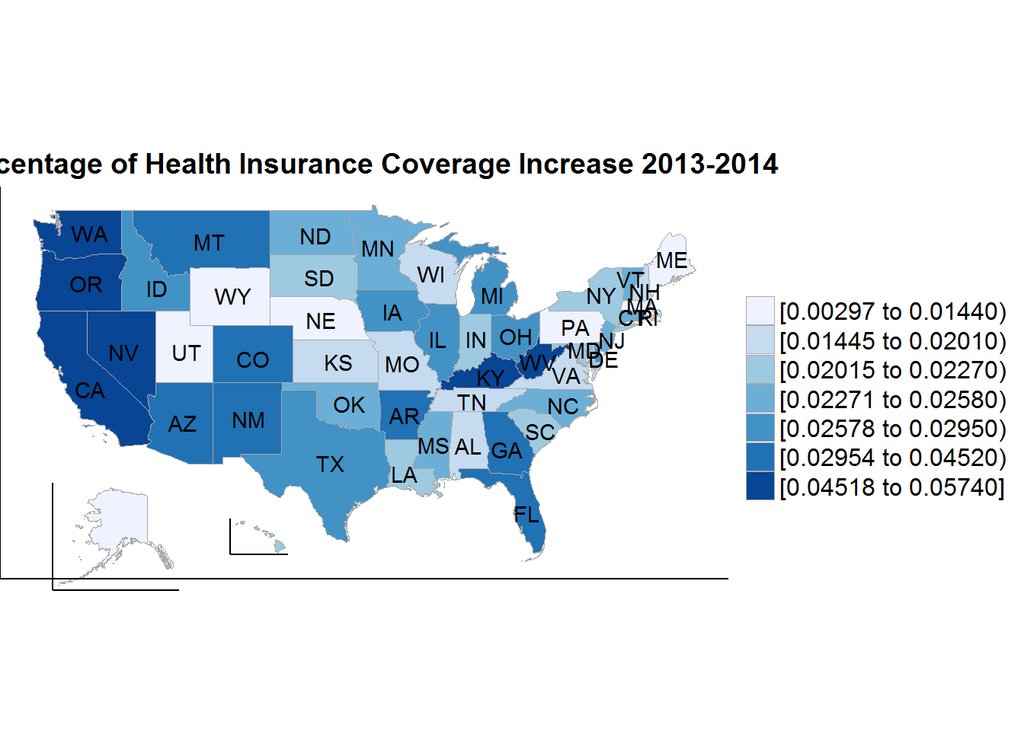

```r
ins14$ins_per_change <- ins14$ins_per - ins13$ins_per
ins_change <- subset(ins14, select = c('name','ins_per_change'))
ins_change$name <- tolower(ins_change$name)
colnames(ins_change) <- c('region', 'value')
state_choropleth(ins_change, title='Percentage of Health Insurance Coverage Increase 2013-2014')
```

### > Income & Education Level

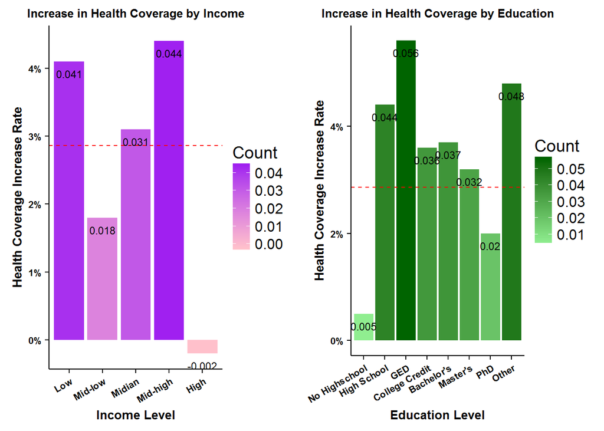

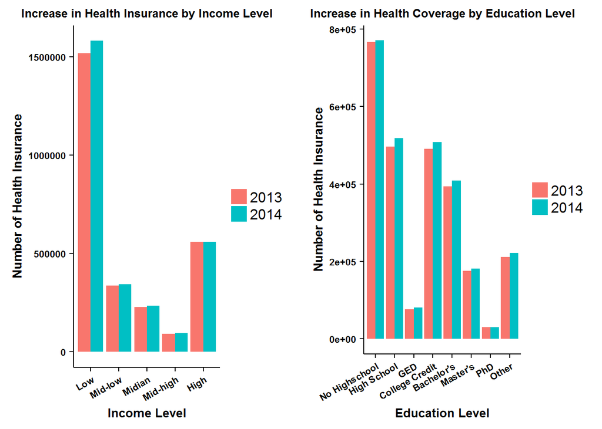

- For the comparison for Income Level and Education Level, simply percentage change doesn’t tell the whole story of what is happening because the baseline of population for each class varies. As seen at the last two graphs, a number of low income people much more outnumber Mid-high class people, and it resulted in a bigger change with a small value difference for Mid-high class.
- With this mind, we observe that low income class people and those with only high school degree are the groups that had a significant increase in health insurance coverage.

## 3. Conclusion

In 2014, more Americans became insured, with the Affordable Care Act most likely to being the main catalyst. Certain individuals were likely to not have insurance, and these individuals were most likely to have insurance. As ObamaCare was meant to be for those who need financial assistance to get insurance, it is reasonalbe that those who meet the criteria such as low income class have a larger increase in health insurance enrollments. It could have been more accurate if we had data that specifies a source of insurance, indicating whether or not a person was a beneficiary of ObamaCare. Although insurance information we used include both private and public insurance, we identified a significant growth in health insurance enrollment especially for targeted groups.